# Green & Impervious Space Visuals

Francine Stephens

Last Updated: May 21, 2021

## Place-Level Graphics

```r
## green v. imperv functions
prep_for_space_time_line_graphs <- function(x) {
  x %>%
   ungroup() %>%
  filter(top100_place == 1) %>%
  mutate(PLACE_NM = str_remove(PLACE_DERIVED_NM, " city"),
         PLACE_ST_NM = str_c(PLACE_NM, state_ab, sep = ", ")
  ) %>%
  group_by(PLACE_ST_NM, region, wave) %>%
  summarize(impervious = sum(imperv_area),
            green = median(med_pct_veg),
            area = sum(area)
            ) %>%
  ungroup() %>%
  mutate(perc_imperv = (impervious/area) * 100) %>%
  rename(perc_green = "green") %>%
  pivot_longer(
               cols = starts_with("perc_"),
               names_to = "landcover",
               values_to = "percent"
               )
}

make_imp_green_line_graphs <- function(x) {
  x %>%
  ggplot(aes(wave, percent, group = PLACE_ST_NM)) +
  geom_line(aes(color=PLACE_ST_NM), size = 1.2) +
  geom_point(aes(color=PLACE_ST_NM), size = 1.5) +
  scale_color_brewer(palette = "Set2") +
  labs(
    title = "Share of Green and Impervious Space in Selected Cities",
    x = "Year",
    y = "% of Area",
    color = "Places") +
  ggthemes::theme_fivethirtyeight() +
  #theme_light() +
  facet_wrap(~ landcover)
}

# Imperv functions by racial composition subset
create_racial_comp_for_imp_lines <- function(x) {
  x %>%
  ungroup() %>%
  filter(top100_place == 1) %>%
  mutate(PLACE_NM = str_remove(PLACE_DERIVED_NM, " city"),
         PLACE_ST_NM = str_c(PLACE_NM, state_ab, sep = ", "),
         majority_minority = if_else(WHITE_NH_PCT < 50,
                                     "Majority Nonwhite",
                                     "Majority white"),
         race_comp = case_when(
           majority_minority == "Majority white" ~ "Majority white",
           BLACK_NH_PCT > 50  ~ "Majority Black",
           ASIAN_PACIFIC_NH_PCT > 50 ~ "Majority Asian",
           HISPANIC_PCT > 50 ~ "Majority Latinx",
           TRUE  ~ "No Majority"
         )
  ) %>%
  group_by(PLACE_ST_NM, region, race_comp, wave) %>%
  summarize(impervious = sum(imperv_area),
            green = median(med_pct_veg),
            area = sum(area)
            ) %>%
  ungroup() %>%
  mutate(perc_imperv = (impervious/area) * 100) %>%
  rename(perc_green = "green") %>%
  pivot_longer(
               cols = starts_with("perc_"),
               names_to = "landcover",
               values_to = "percent"
               )
}

make_race_comp_imp_line_graph <- function(x) {
  x %>%
  ggplot(aes(wave, percent, group = race_comp)) +
  geom_line(aes(color=race_comp), size = 1.2) +
  geom_point(aes(color=race_comp), size = 1.5) +
  scale_color_manual(values = wes_palette("Darjeeling1")
                     ) +
  ggthemes::theme_fivethirtyeight() +
  #theme_light() +
  labs(
    title = "Share of Impervious Space by Neighborhood Racial Composition",
    x = "Year",
    y = "% of Area",
    color = "Racial Composition") +
    facet_wrap(~ PLACE_ST_NM)
}
```

### Northeast

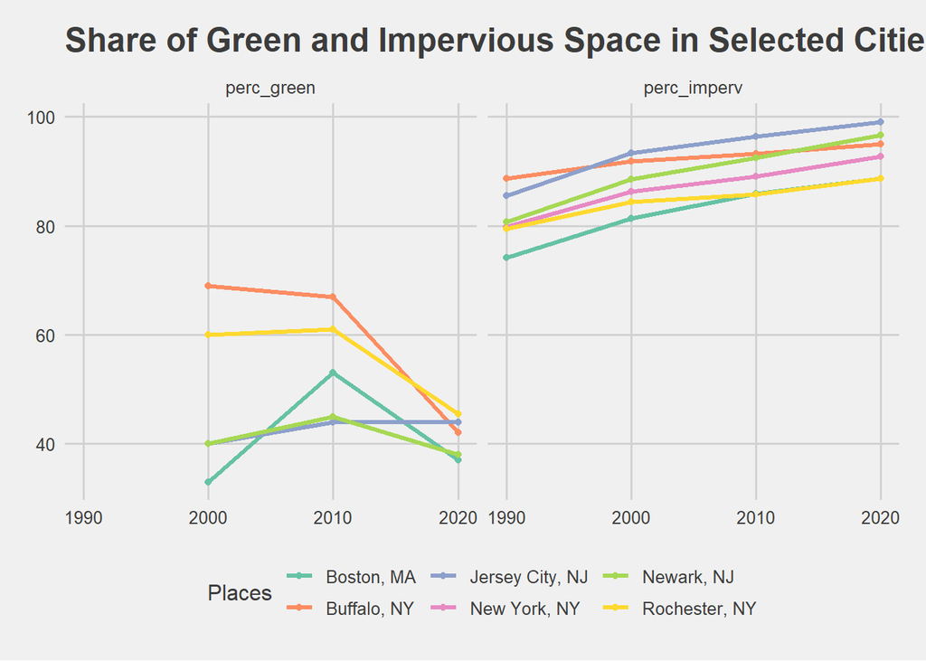

```r
## Northeast
full_cbg_data_l %>%
  prep_for_space_time_line_graphs(.) %>%
  filter(region == "Northeast") %>%
  make_imp_green_line_graphs(.)
```

**Impervious Space By Neighborhood Racial Composition**

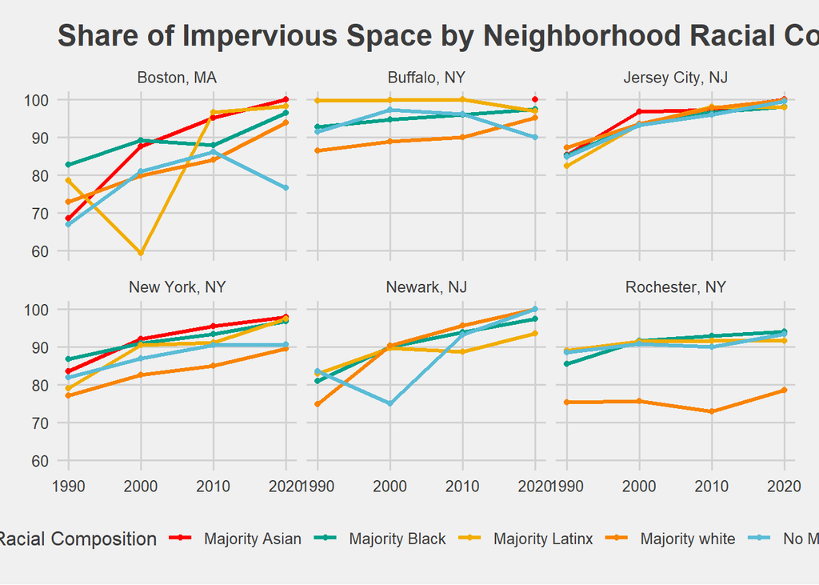

```r
## NE RACE & IMPERVIOUS SPACE
full_cbg_data_l %>%
  create_racial_comp_for_imp_lines(.) %>%
  filter(region == "Northeast" & landcover == "perc_imperv") %>%
  make_race_comp_imp_line_graph(.)
```

White neighborhoods with less impervious space than minority majority neighborhoods:

- New York, NY
- Rochester, NY.

Similar level of impervious space across all types of neighborhoods:

- Jersey City, NJ

No racial majority trends downward:

- Boston, MA after 2010
- Buffalo, NY after 2010

### Mid-Atlantic

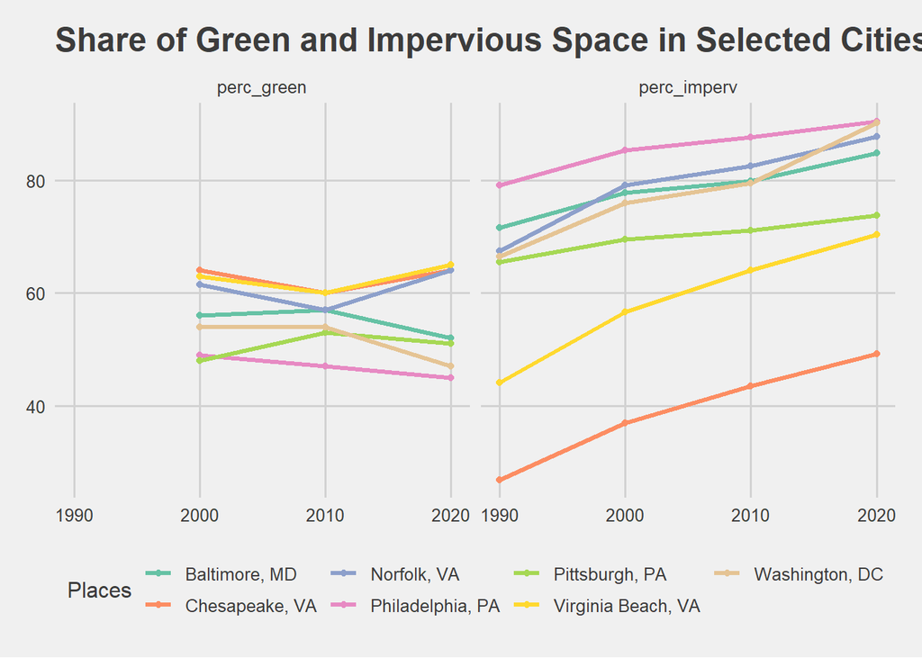

```r
## Mid-Atlantic
full_cbg_data_l %>%
  prep_for_space_time_line_graphs(.) %>%
  filter(region == "Mid-Atlantic") %>%
  make_imp_green_line_graphs(.)
```

**Impervious Space By Neighborhood Racial Composition**

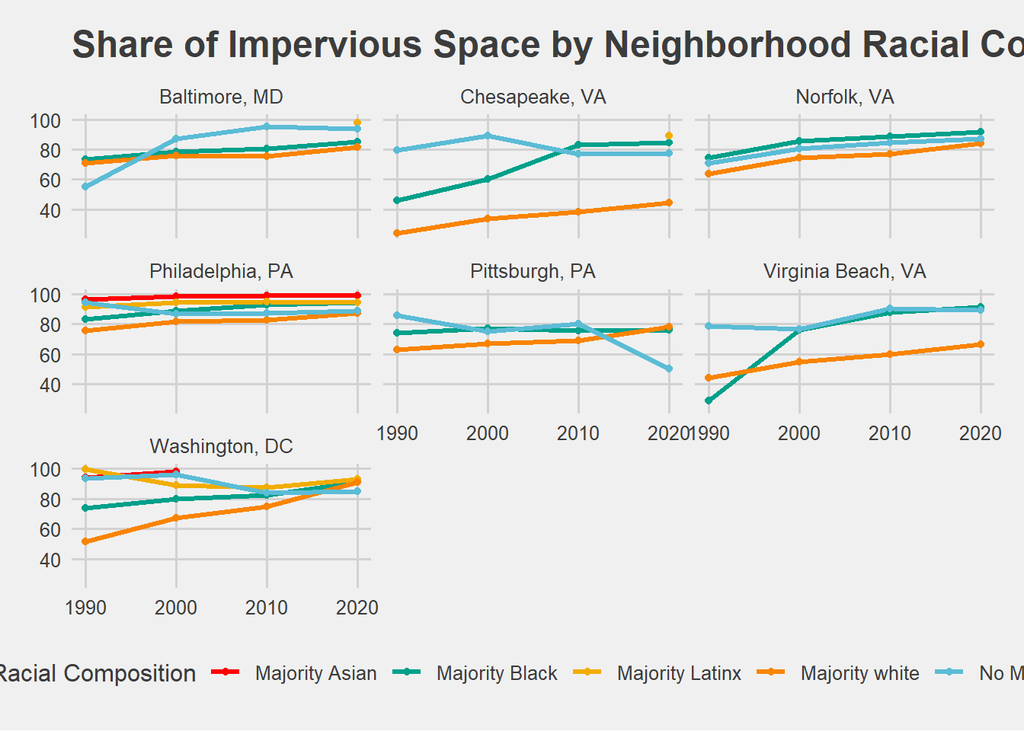

```r
## Mid-Atl RACE & IMPERVIOUS SPACE
full_cbg_data_l %>%
  create_racial_comp_for_imp_lines(.) %>%
  filter(region == "Mid-Atlantic" & landcover == "perc_imperv") %>%
  make_race_comp_imp_line_graph(.)
```

White neighborhoods with less built up space than minority majority neighborhoods:

- Chesapeake, VA
- Virginia Beach, VA

Declining impervious space among neighborhoods with no racial/ethnic majority:

- Philadelphia, PA
- Pittsburgh, PA
- Washington, DC
- Chesapeake, VA

Increasing impervious space among neighborhoods with no racial/ethnic majority:

- Baltimore, MD
- Norfolk, VA
- Virginia Beach, VA

White neighborhoods with growing amounts of impervious space:

- Pittsburgh
- DC

### Midwest

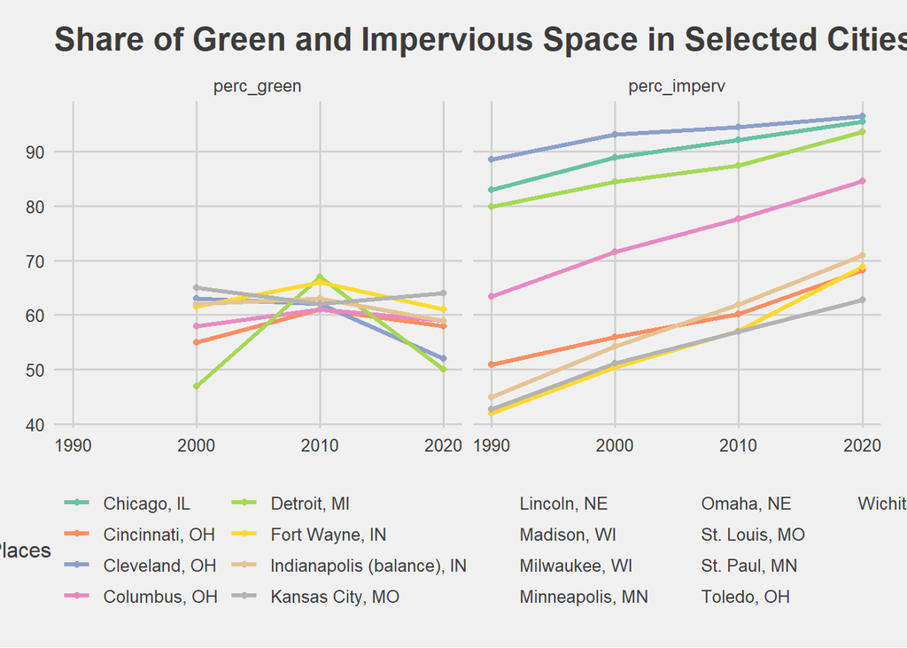

```r
## Midwest
full_cbg_data_l %>%
  prep_for_space_time_line_graphs(.) %>%
  filter(region == "Midwest") %>%
  make_imp_green_line_graphs(.)
```

**Impervious Space By Neighborhood Racial Composition**

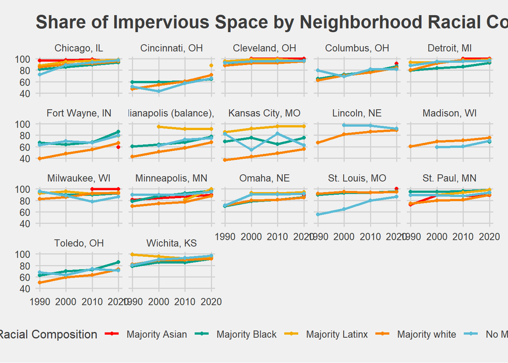

```r
## Midwest RACE & IMPERVIOUS SPACE
full_cbg_data_l %>%
  create_racial_comp_for_imp_lines(.) %>%
  filter(region == "Midwest" & landcover == "perc_imperv") %>%
  make_race_comp_imp_line_graph(.)
```

White neighborhoods with less built up space than minority majority neighborhoods:

- Fort Wayne, IN
- Indianapolis, IN
- Kansas City, MO
- Lincoln, NE (to a lesser extent)
- Toledo, OH (to a lesser extent)

### South

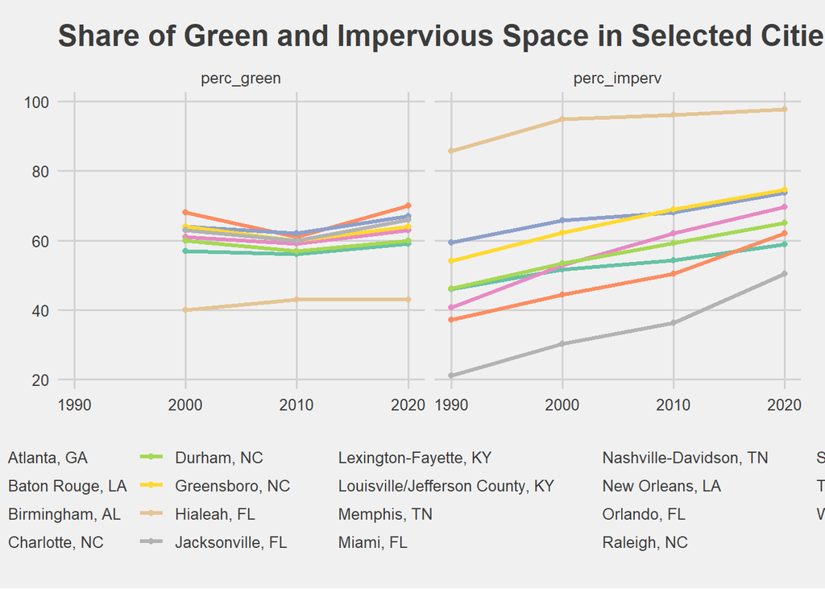

```r
## South
full_cbg_data_l %>%
  prep_for_space_time_line_graphs(.) %>%
  filter(region == "South") %>%
  mutate(PLACE_ST_NM = str_remove(PLACE_ST_NM, " urban county"),
         PLACE_ST_NM = str_remove(PLACE_ST_NM, " government"),
         PLACE_ST_NM = str_remove(PLACE_ST_NM, " metropolitan"),
         PLACE_ST_NM = str_remove(PLACE_ST_NM, " metro"),
         PLACE_ST_NM = gsub("\\s*\\([^\\)]+\\)", "", PLACE_ST_NM)
         ) %>%
  make_imp_green_line_graphs(.)
```

**Impervious Space By Neighborhood Racial Composition**

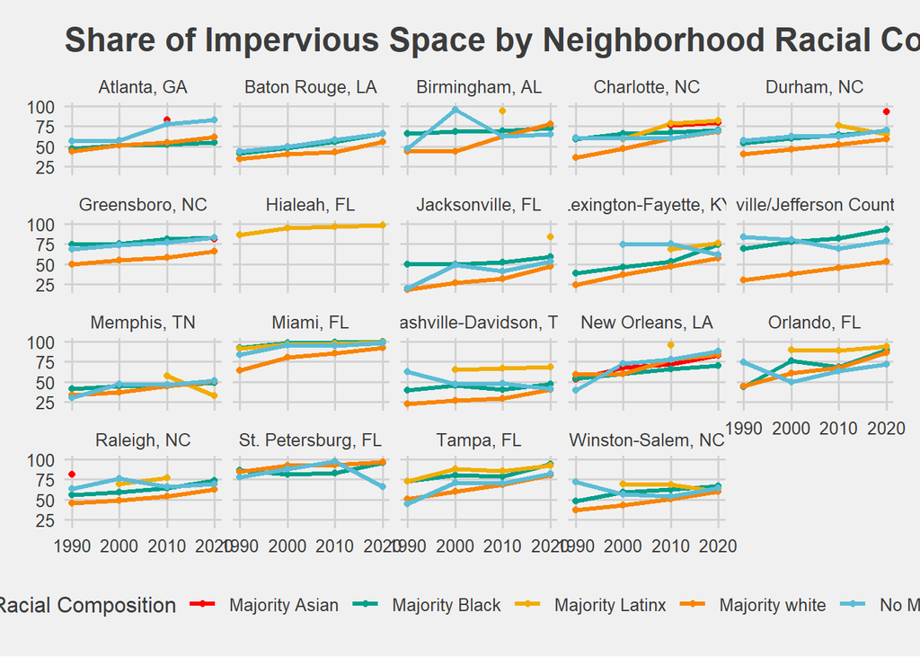

```r
## South RACE & IMPERVIOUS SPACE
full_cbg_data_l %>%
  create_racial_comp_for_imp_lines(.) %>%
  filter(region == "South" & landcover == "perc_imperv") %>%
  mutate(PLACE_ST_NM = str_remove(PLACE_ST_NM, " urban county"),
         PLACE_ST_NM = str_remove(PLACE_ST_NM, " government"),
         PLACE_ST_NM = str_remove(PLACE_ST_NM, " metropolitan"),
         PLACE_ST_NM = str_remove(PLACE_ST_NM, " metro"),
         PLACE_ST_NM = gsub("\\s*\\([^\\)]+\\)", "", PLACE_ST_NM)
         ) %>%
  make_race_comp_imp_line_graph(.)
```

White neighborhoods with less built up space than minority majority neighborhoods:

- Baton Rouge, LA
- Greensboro, NC
- Jacksonville, FL
- Louisville, KY
- Miami (?)

### Southwest

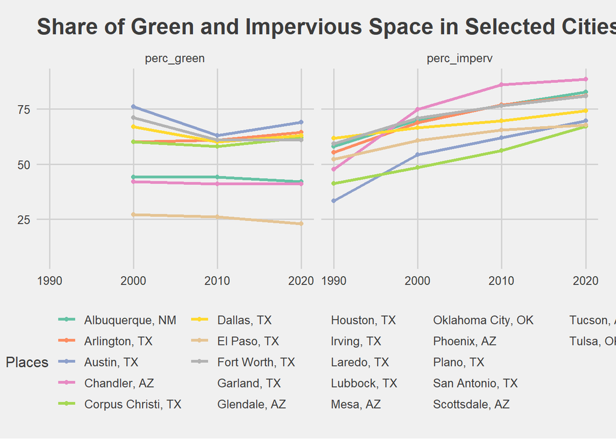

```r
## Southwest
full_cbg_data_l %>%
  prep_for_space_time_line_graphs(.) %>%
  filter(region == "Southwest") %>%
  make_imp_green_line_graphs(.)
```

**Impervious Space By Neighborhood Racial Composition**

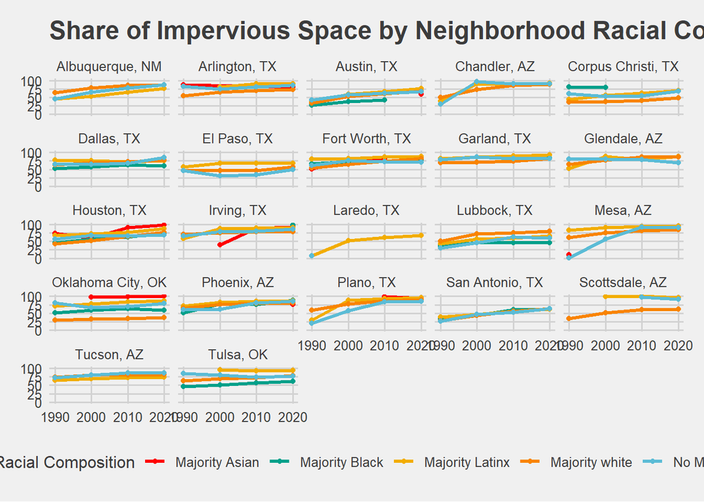

```r
## Southwest RACE & IMPERVIOUS SPACE
full_cbg_data_l %>%
  create_racial_comp_for_imp_lines(.) %>%
  filter(region == "Southwest" & landcover == "perc_imperv") %>%
  make_race_comp_imp_line_graph(.)
```

White neighborhoods with less built up space than minority majority neighborhoods:

- Oklahoma City, OK
- Scottsdale, AZ
- Corpus Christi (?)

**Bexar County, TX: County Seat: San Antonio, TX**

```r
bexar_all_data <- full_cbg_data_l %>%
  ungroup() %>%
  filter(state_co == "48029")

bexar_shp <- cbg10 %>%
  select(GEOID10, STATEFP10, COUNTYFP10) %>%
  right_join(bexar_all_data, by ="GEOID10")
```

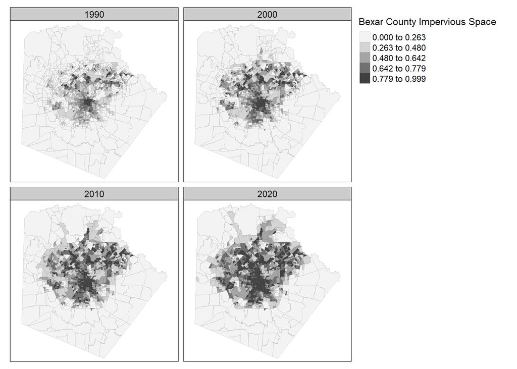

```r
tm_shape(bexar_shp) +
  tm_polygons("perc_imperv",
              style="quantile",
              palette="Greys",
              title="Bexar County Impervious Space",
              border.alpha = 0.2) +
      tm_facets(by = "wave")
```

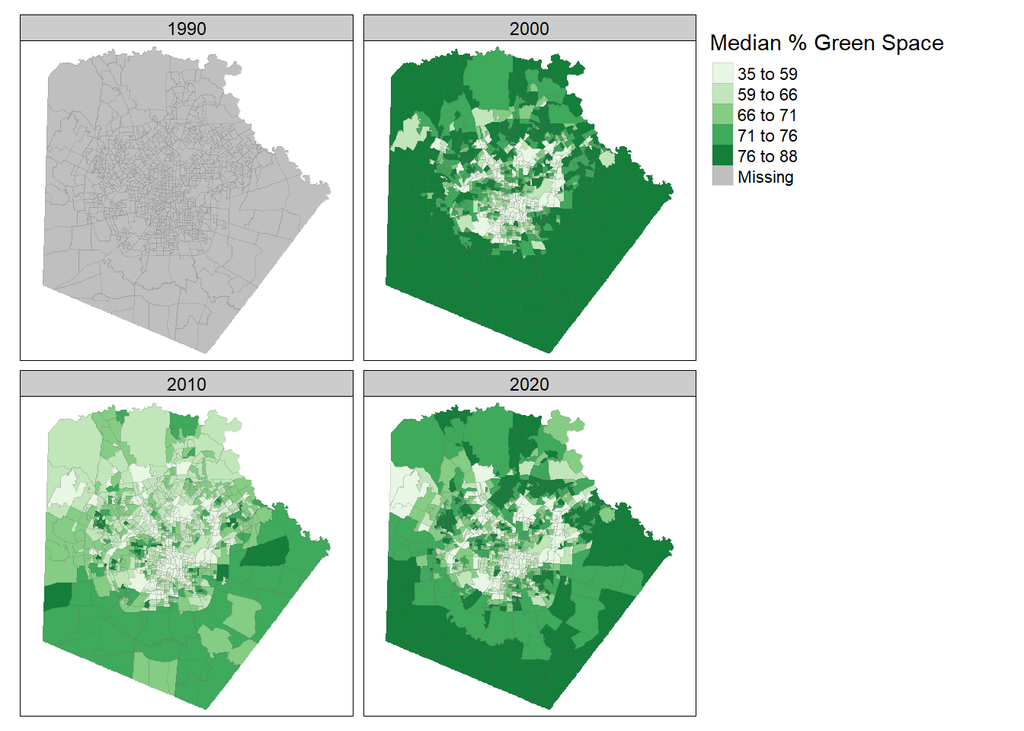

```r
tm_shape(bexar_shp) +
  tm_polygons("med_pct_veg",
              style="quantile",
              palette="Greens",
              title="Median % Green Space",
              border.alpha = 0.2) +
      tm_facets(by = "wave")
```

```r
#green_bexar_evi <-
  tm_shape(bexar_shp) +
  tm_polygons("perc_green",
              style="quantile",
              palette="Greens",
              title="Green Space by EVI",
              border.alpha = 0.2) +
      tm_facets(by = "wave")
```

[figure not shown]

### Mountain West

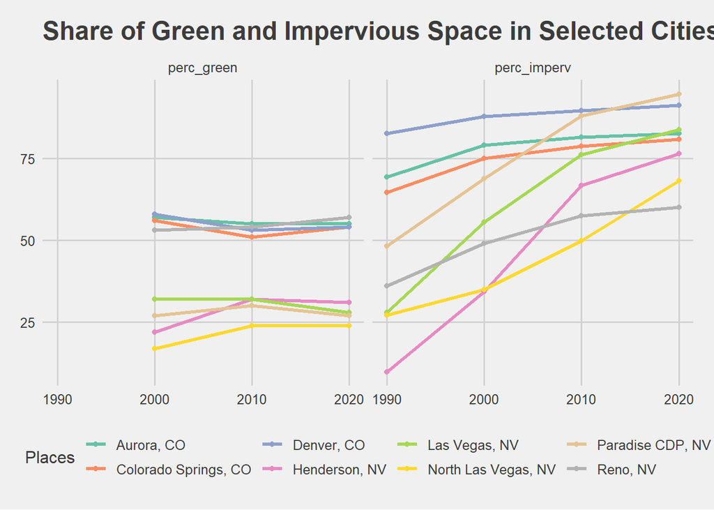

```r
## West
full_cbg_data_l %>%
  prep_for_space_time_line_graphs(.) %>%
  filter(region == "West") %>%
  make_imp_green_line_graphs(.)
```

**Impervious Space By Neighborhood Racial Composition**

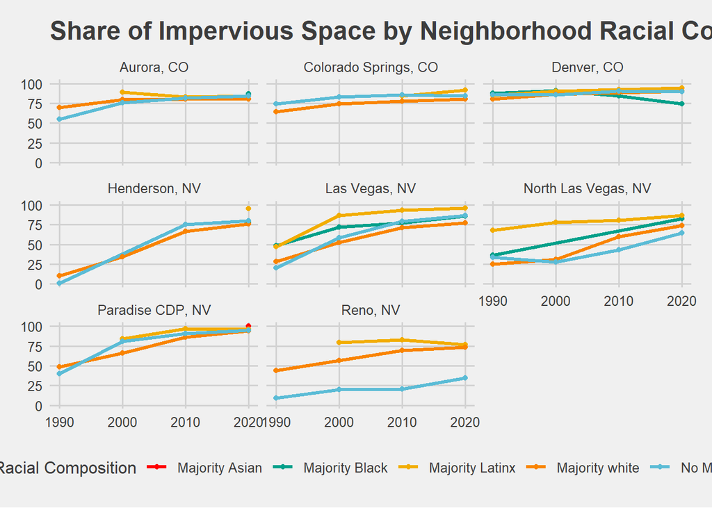

```r
## Mountain RACE & IMPERVIOUS SPACE
full_cbg_data_l %>%
  create_racial_comp_for_imp_lines(.) %>%
  filter(region == "West" & landcover == "perc_imperv") %>%
  make_race_comp_imp_line_graph(.)
```

### Pacific West

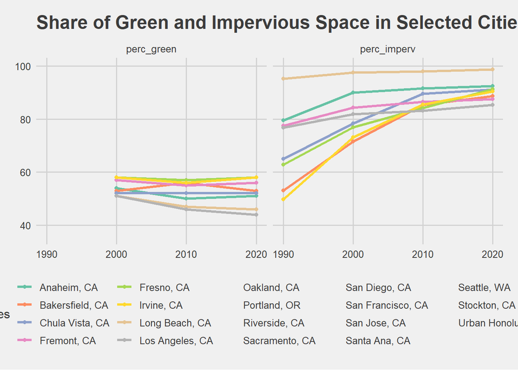

```r
## Pacific
full_cbg_data_l %>%
  prep_for_space_time_line_graphs(.) %>%
  filter(region == "Pacific" & PLACE_ST_NM != "Anchorage municipality, AK") %>%
  make_imp_green_line_graphs(.)
```

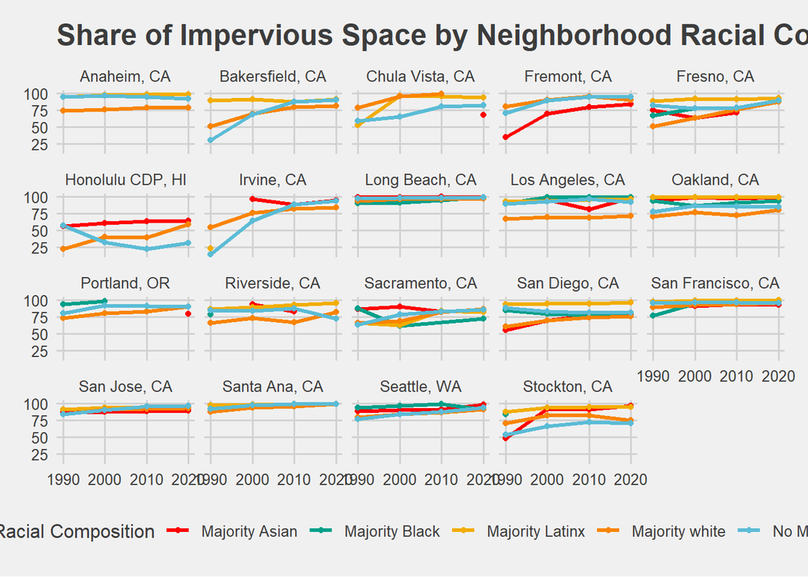

```r
## PACIFIC RACE & IMPERVIOUS SPACE
full_cbg_data_l %>%
  create_racial_comp_for_imp_lines(.) %>%
  filter(region == "Pacific" & PLACE_ST_NM != "Anchorage municipality, AK") %>%
  filter(landcover == "perc_imperv") %>%
  mutate(PLACE_ST_NM = str_remove(PLACE_ST_NM, "Urban ")) %>%
  make_race_comp_imp_line_graph(.)
```

White neighborhoods with less built up space than minority majority neighborhoods:

- Anaheim, CA
- Los Angeles, CA (?)

## Metro-level Graphics

**SA, TX METRO**

```r
satx_metro <- full_cbg_data_l %>%
  ungroup() %>%
  filter(cbsacode == "41700")

satx_metro_shp <- cbg10 %>%
  select(GEOID10, STATEFP10, COUNTYFP10) %>%
  right_join(satx_metro, by ="GEOID10")
```

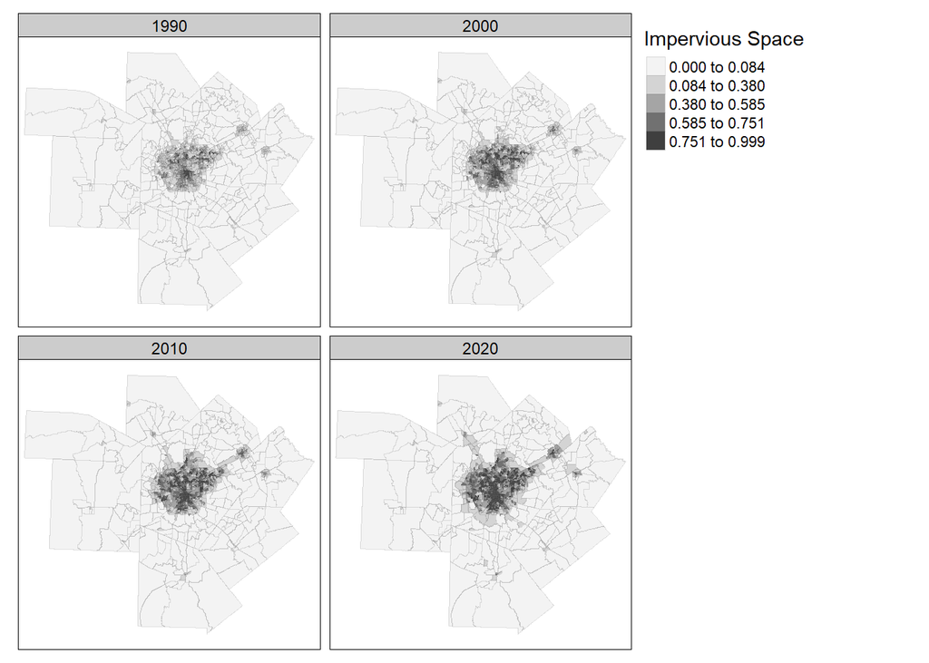

```r
tm_shape(satx_metro_shp) +
  tm_polygons("perc_imperv",
              style="quantile",
              palette = "Greys",
              title="Impervious Space",
              border.alpha = 0.2) +
      tm_facets(by = "wave")
```

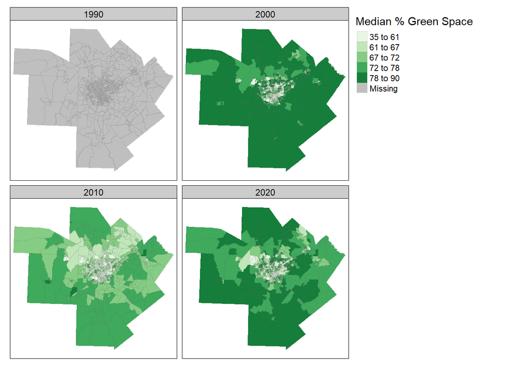

```r
tm_shape(satx_metro_shp) +
  tm_polygons("med_pct_veg",
              style="quantile",
              palette = "Greens",
              title="Median % Green Space",
              border.alpha = 0.2) +
      tm_facets(by = "wave")
```

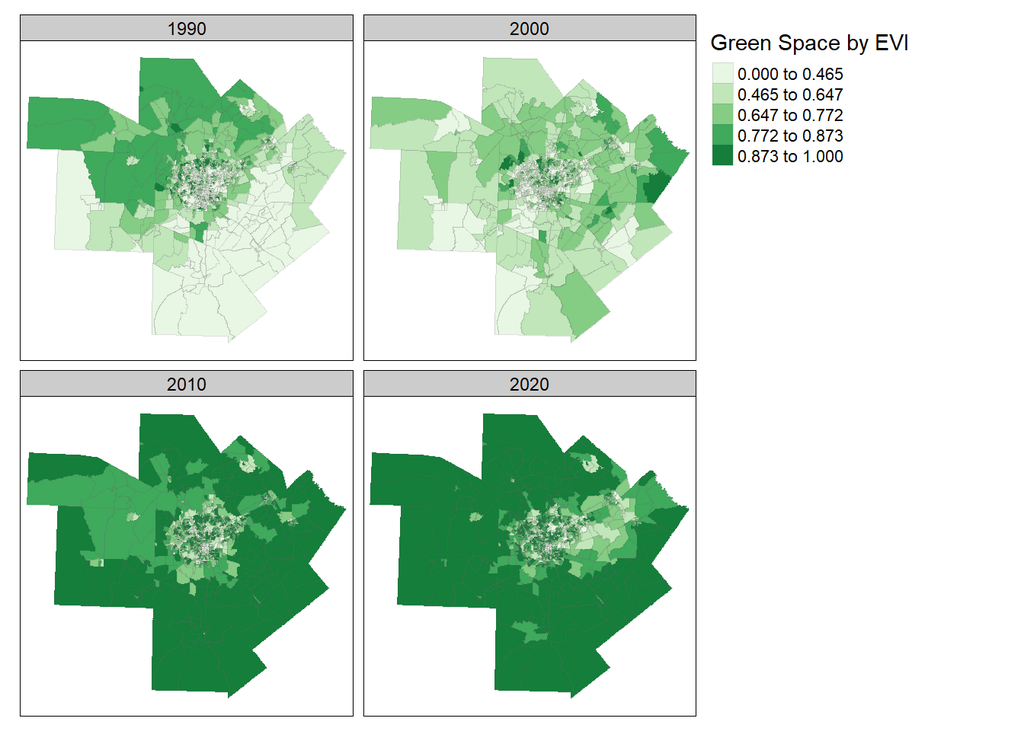

```r
tm_shape(satx_metro_shp) +
  tm_polygons("perc_green",
              style="quantile",
              palette = "Greens",
              title="Green Space by EVI",
              border.alpha = 0.2) +
      tm_facets(by = "wave")
```